# 19 Tree and Flow charts

Let’s finish our presentation of charts by introducing 2 different types :

- **collapsible trees**.
- **flow charts**.

We upload first the libraries that we will use : `tidyverse` for the ETL and 2 new ones for the charts we will present, `collapsibleTree` and `ggflowchart` .

```r
# ETL
library(tidyverse)

# Charts
library(collapsibleTree)
library(ggflowchart)
```

# 20 collapsibleTree

`collapsibleTree` is a package that creates interactive, collapsible Reingold-Tilford tree diagrams based on `D3.js`. It enables users **to visualize hierarchical data directly from data frames by clicking to expand or collapse nodes**, making it ideal for exploring complex, nested structures.

2 classic usages in Supply Chain would be to visualize :

- a BOM (Bill Of Materials), through multiple levels.
- a flow of products through a Distribution Network.

Here is the github page for the package : https://github.com/AdeelK93/collapsibleTree

Let’s create a simple example to illustrate it.

First, we will download a data frame with 5 variables :

- **4 dimensions** : Factory | Regional.DC (Distribution Center) | Country.DC | Product.
- **1 measure** : Quantity (of sales).

This data frame shows :

- the Quantity sold of each product in each Country.DC .
- how is supplied each Country.DC : from a Regional.DC or from a Factory .

```r
# Upload data frame

# Define the URL of the raw CSV file
url <- "https://raw.githubusercontent.com/nguyennico/chart_practice/main/Regional_Network_data.csv"

# Read the CSV file from the URL
df1 <- read.csv(url)


df1
```

```
   Factory Regional.DC   Country.DC   Product Quantity
1    Perth                 Auckland Product A     1000
2    Perth                 Auckland Product B     2000
3    Perth                 Auckland Product C      800
4    Perth                   Taipei Product A     3200
5    Perth                   Taipei Product B     1700
6    Perth                   Taipei Product C     1000
7    Perth   Singapore    Singapore Product A      400
8    Perth   Singapore    Singapore Product B      900
9    Perth   Singapore    Singapore Product C     2000
10   Perth   Singapore Kuala Lumpur Product A     1300
11   Perth   Singapore Kuala Lumpur Product B     2400
12   Perth   Singapore Kuala Lumpur Product C      800
13   Perth   Singapore      Bangkok Product A      900
14   Perth   Singapore      Bangkok Product B     1800
15   Perth   Singapore      Bangkok Product C     1400
```

Now, let’s use the function `collapsibleTree()` to display this data frame into a *Reingold-Tilford tree diagram*.

We inform 3 values :

- **the data frame**.
- **the order of display of the variables** : here from the Factory (on the left) to the Product (on the right).
- **whether we want the diagram to be collapsed** (`= TRUE`) or not (`= FALSE`).

```r
# create chart
collapsibleTree(df1,
                c("Factory", "Regional.DC", "Country.DC", "Product"),
                collapsed = FALSE
                )
```

[interactive chart not shown]

Here is the same example, collapsing the nodes . By clicking on the nodes we can expand or close them.

```r
# create chart
collapsibleTree(df1,
                c("Factory", "Regional.DC", "Country.DC", "Product"),
                collapsed = TRUE
                )
```

[interactive chart not shown]

# 21 ggflowchart

`ggflowchart` is an R package that enables users **to create, customize, and plot simple, aesthetic flowcharts** using the `ggplot2` framework.

It requires minimal code, **taking data frames with “from” and “to” columns to generate diagrams**, with options for customizing colors, layout orientation, and text.

To illustrate it, let’s create a simple data frame :

- **only 2 variables : from and to .**
- **the value on the left is directed to the one on the right .**

```r
# create data frame
data <- data.frame(from = c(rep("Portfolio", 4),
                                rep("Family A", 3),
                                rep("Family B", 3),
                                rep("Family C", 3),
                                rep("Family D", 3)
                                ),

                       to = c("Family A", "Family B", "Family C", "Family D",
                              "Item 1", "Item 2", "Item 3",
                              "Item 4", "Item 5", "Item 6",
                              "Item 7", "Item 8", "Item 9",
                              "Item 10", "Item 11", "Item 12"
                              )
                       )

data
```

```
        from       to
1  Portfolio Family A
2  Portfolio Family B
3  Portfolio Family C
4  Portfolio Family D
5   Family A   Item 1
6   Family A   Item 2
7   Family A   Item 3
8   Family B   Item 4
9   Family B   Item 5
10  Family B   Item 6
11  Family C   Item 7
12  Family C   Item 8
13  Family C   Item 9
14  Family D  Item 10
15  Family D  Item 11
16  Family D  Item 12
```

Now let’s create a flow chart, using the function `ggflowchart()` .

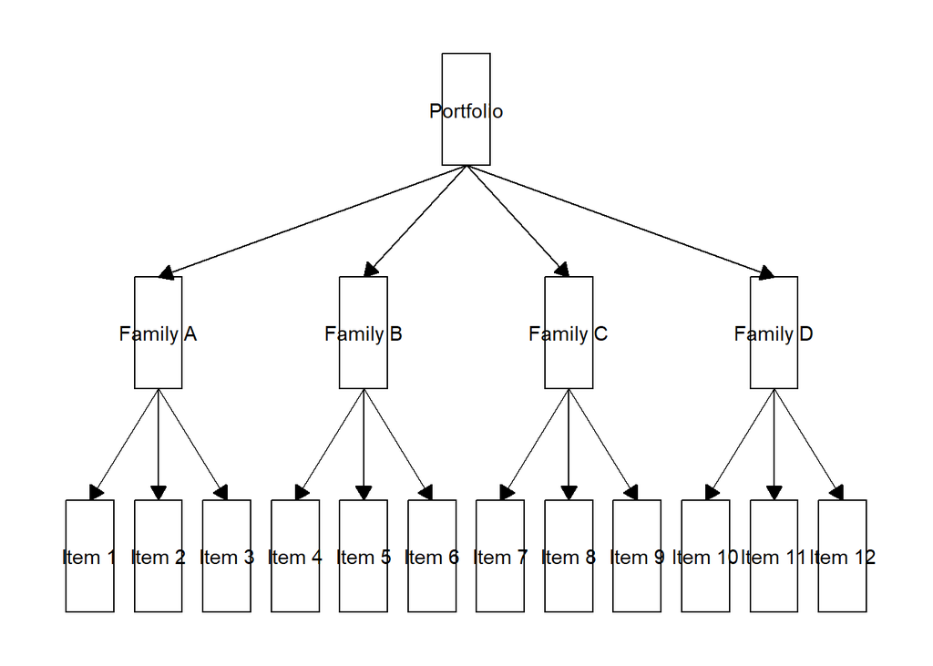

```r
ggflowchart(data)
```

We quickly generated a flow, or to be more precised here, a hierarchy chart.

To know more about it, we can visit the website page of the author Nicola Rennie : [Introducing {ggflowchart} – Nicola Rennie](https://nrennie.rbind.io/blog/introducing-ggflowchart/)

The are also other related packages, for example `flowchart` for drawing participant flow diagrams directly from a data frame using tidyverse : https://github.com/bruigtp/flowchart